# Question

An [ellipse](https://en.wikipedia.org/wiki/Ellipse) is the set of ($x$, $y$) points that satisfy the equation below.

$$\frac{(x-h)^2}{(r_1)^2}+\frac{(y-k)^2}{(r_2)^2}=1$$

where the center is $(h,k)$, the horizontal radius is $r_1$, and the vertical radius is $r_2$.

Determine the parameters of the ellipse in the graph below. You can assume all parameters are integers.

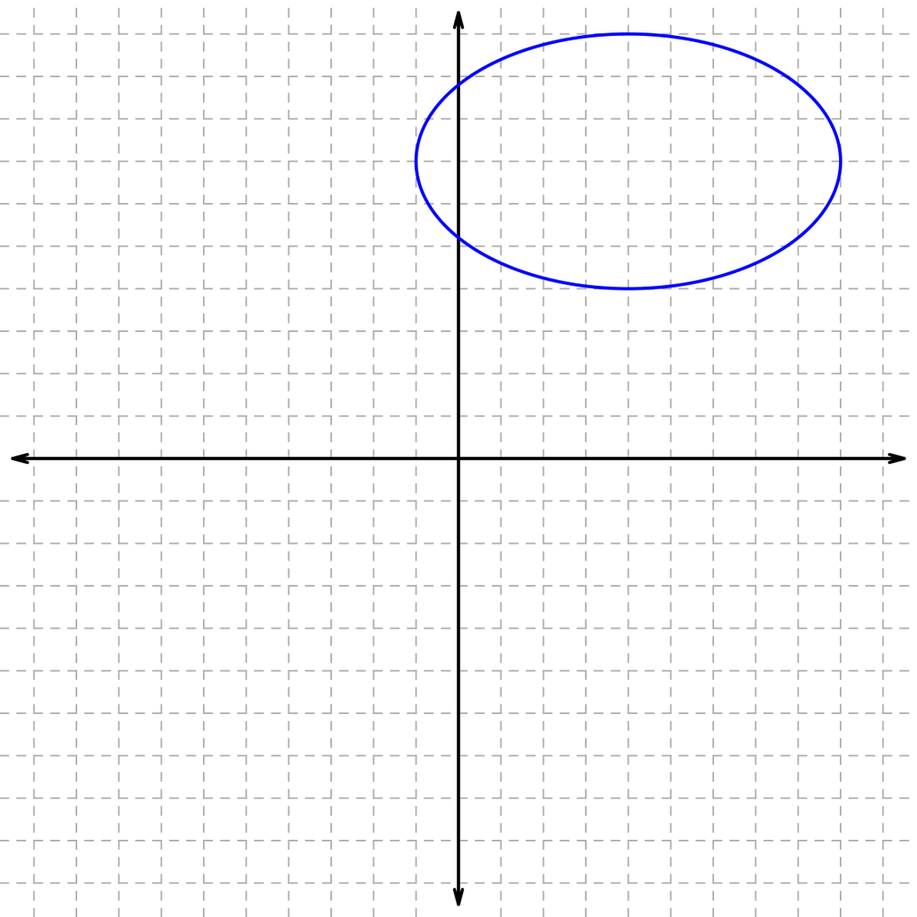

- $h=$ ##ANSWER1##
- $k=$ ##ANSWER2##
- $r_1=$ ##ANSWER3##
- $r_2=$ ##ANSWER4##

Which of the following equations would give the graph above?

$$\begin{align}
A&:~~\frac{(x+4)^2}{9}+\frac{(y+7)^2}{25}=1 &
B&:~~\frac{(x+4)^2}{9}+\frac{(y-7)^2}{25}=1 &
C&:~~\frac{(x-4)^2}{9}+\frac{(y+7)^2}{25}=1 &
D&:~~\frac{(x-4)^2}{9}+\frac{(y-7)^2}{25}=1 \\
E&:~~\frac{(x+7)^2}{9}+\frac{(y+4)^2}{25}=1 &
F&:~~\frac{(x+7)^2}{9}+\frac{(y-4)^2}{25}=1 &
G&:~~\frac{(x-7)^2}{9}+\frac{(y+4)^2}{25}=1 &
H&:~~\frac{(x-7)^2}{9}+\frac{(y-4)^2}{25}=1 \\
I&:~~\frac{(x+4)^2}{25}+\frac{(y+7)^2}{9}=1 &
J&:~~\frac{(x+4)^2}{25}+\frac{(y-7)^2}{9}=1 &
K&:~~\frac{(x-4)^2}{25}+\frac{(y+7)^2}{9}=1 &
L&:~~\frac{(x-4)^2}{25}+\frac{(y-7)^2}{9}=1 \\
M&:~~\frac{(x+7)^2}{25}+\frac{(y+4)^2}{9}=1 &
N&:~~\frac{(x+7)^2}{25}+\frac{(y-4)^2}{9}=1 &
O&:~~\frac{(x-7)^2}{25}+\frac{(y+4)^2}{9}=1 &
P&:~~\frac{(x-7)^2}{25}+\frac{(y-4)^2}{9}=1 \\
\end{align}$$

Equation ##ANSWER5##

## Answerlist

- -10
- -9
- -8
- -7
- -6
- -5
- -4
- -3
- -2
- -1
- 0
- 1
- 2
- 3
- 4
- 5
- 6
- 7
- 8
- 9
- 10
- -10
- -9
- -8
- -7
- -6
- -5
- -4
- -3
- -2
- -1
- 0
- 1
- 2
- 3
- 4
- 5
- 6
- 7
- 8
- 9
- 10
- 1
- 2
- 3
- 4
- 5
- 6
- 7
- 8
- 9
- 10
- 1
- 2
- 3
- 4
- 5
- 6
- 7
- 8
- 9
- 10
- A
- B
- C
- D
- E
- F
- G
- H
- I
- J
- K
- L
- M
- N
- O
- P

# Solution

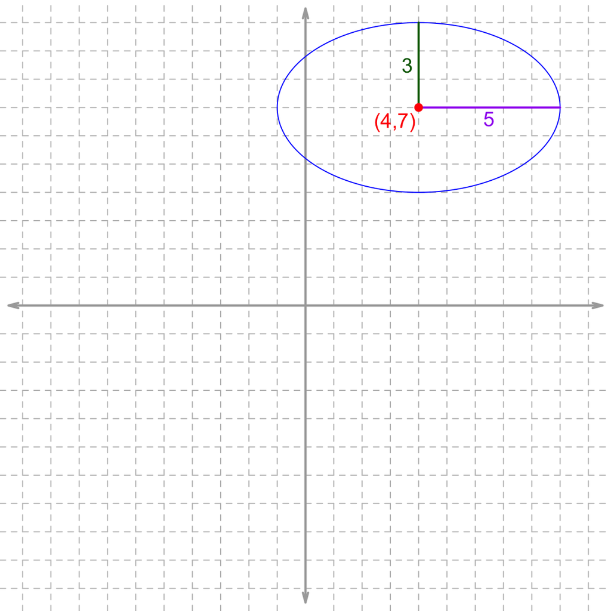

So:
$$\begin{align}
h &= 4\\\\
k &= 7\\\\
r_1 &= 5\\\\
r_2 &= 3
\end{align}$$

Substitute those numbers into the equation:

$$\frac{(x-4)^2}{25}+\frac{(y-7)^2}{9}=1$$

# Meta-information

extype: cloze exclozetype: schoice|schoice|schoice|schoice|schoice exsolution: 000000000000001000000|000000000000000001000|0000100000|0010000000|0000000000010000 exname: ellipse_get_pams